# Partisanship and Competitive Elections: Notebook 6

Keith Colella

2023-05-14

```r
library(tidyverse)
library(infer)
library(tigris)
library(sf)
library(kableExtra)
library(cowplot)

set.seed(888)
```

## Abstract

In this paper, I investigate the relationship between the competitiveness of electoral districts and the partisan leanings of candidates elected in those districts. The predominating narrative on partisan gerrymandering posits that redistricting efforts led by one-sided state legislatures leads to one-sided, uncompetitive congressional races, in which one party is heavily favored in most districts. In turn this lack of competition contributes to polarization, as the “real” races take place during primary elections, in which candidates are incentivized to take more extreme positions to appeal to their parties’ political bases. This narrative is compelling, but I have found very limited empirical evidence to support it. Therein lies the goal of the analysis I put forth below: is there empirical support linking a lack of competitiveness with more polarizing candidates?

Because these phenomena are not directly observable — referred to as “latent” variables — I consider six different proxy variables that attempt to quantify competitiveness and partisanship. To attempt to measure competitiveness, I consider three variables: the results of a 2022 study measuring voter policy preferences (referred to below as the “Ideology” measure; see [1]), the Cook Partisan Voting Index (referred to as “Cook PVI”; see [2]), and the average, district-level “efficiency gap” for all congressional elections since 2010 (see [3]). As a proxy of how far left or right candidates lean, I consider another three variables: the NOMINATE measure of ideological leanings in Congressional voting, popularized by Poole and Rosenthal (referred to as “Nominate”; see [4]), GovTrack’s measure of partisan cooperation in Congress (referred to as “Govtrack”; see [5]) and a “homemade” measure of partisan rhetoric based on predictive modeling performed on a corpus candidate tweets.

## Data

Primary data

```r
candidates <- read_csv('data/candidates_partisan_compete.csv')
glimpse(candidates)
```

```
## Rows: 4,297
## Columns: 18
## $ fec_id                  <chr> "H2CO07170", "H2UT03280", "H2CA30291", "H2MN07…
## $ name                    <chr> "AADLAND, ERIK", "AALDERS, TIM", "AAZAMI, SHER…
## $ state                   <chr> "CO", "UT", "CA", "MN", "NY", "MN", "OH", "CA"…
## $ district                <chr> "07", "03", "32", "07", "12", "05", "09", "50"…
## $ party                   <chr> "REPUBLICAN PARTY", "REPUBLICAN PARTY", "DEMOC…
## $ office                  <chr> "House", "House", "House", "House", "House", "…
## $ incumbent_challenge     <chr> "Open seat", "Challenger", "Challenger", "Chal…
## $ candidate_status        <chr> "P", "C", "N", "P", "P", "P", "N", "C", "N", "…
## $ bioguide_id             <chr> NA, NA, NA, NA, NA, NA, NA, NA, NA, NA, NA, NA…
## $ ballotpedia_id          <chr> "Erik_Aadland", "Tim_Aalders", "Shervin_Aazami…
## $ govtrack_id             <dbl> NA, NA, NA, NA, NA, NA, NA, NA, NA, NA, NA, NA…
## $ twitter_name            <chr> "aadlandforco", NA, "aazamishervin", NA, NA, N…
## $ partisan_score_twitter  <dbl> 0.4659687, NA, NA, NA, NA, NA, NA, NA, NA, NA,…
## $ partisan_score_nominate <dbl> NA, NA, NA, NA, NA, NA, NA, NA, NA, NA, NA, NA…
## $ partisan_score_govtrack <dbl> NA, NA, NA, NA, NA, NA, NA, NA, NA, NA, NA, NA…
## $ compete_ideology        <dbl> 0.03679439, 0.37553384, 0.59131146, 0.54685173…
## $ compete_cookpvi         <dbl> 0.01369863, 0.45205479, 0.45205479, 0.61643836…
## $ compete_eff_gap         <dbl> 0.43740634, 0.03439195, 0.50331208, 0.46466341…
```

```r
candidates <- candidates %>%
  mutate(moc = if_else(is.na(bioguide_id), 'No', 'Yes')) %>%
  select(name, state, district, party, incumbent_challenge, moc,
         contains('partisan'), contains('compete'))

candidates <- candidates[!duplicated(candidates),]

candidates[duplicated(candidates$name) | duplicated(candidates$name, fromLast = TRUE),]
```

```
## # A tibble: 127 × 12
##    name    state district party incumbent_challenge moc   partisan_score_twitter
##    <chr>   <chr> <chr>    <chr> <chr>               <chr>                  <dbl>
##  1 AUSTIN… MT    00       REPU… Challenger          No                        NA
##  2 AUSTIN… MT    00       REPU… Challenger          No                        NA
##  3 AUSTIN… MT    00       REPU… Challenger          No                        NA
##  4 AUSTIN… MT    00       REPU… Challenger          No                        NA
##  5 BALLAR… MT    00       DEMO… Challenger          No                        NA
##  6 BALLAR… MT    00       DEMO… Challenger          No                        NA
##  7 BALLAR… MT    00       DEMO… Challenger          No                        NA
##  8 BALLAR… MT    00       DEMO… Challenger          No                        NA
##  9 BERMAN… MN    01       REPU… Open seat           No                        NA
## 10 BERMAN… MN    06       REPU… Challenger          No                        NA
## # ℹ 117 more rows
## # ℹ 5 more variables: partisan_score_nominate <dbl>,
## #   partisan_score_govtrack <dbl>, compete_ideology <dbl>,
## #   compete_cookpvi <dbl>, compete_eff_gap <dbl>
```

Mapping Data

```r
data('fips_codes')

districts_sf <- congressional_districts() %>%
  st_simplify(dTolerance = 10000) %>%
  data.frame() %>%
  left_join(
    fips_codes %>%
      select(state, state_code) %>%
      unique(),
    by = c('STATEFP' = 'state_code')
  )
states_sf <- states(cb = TRUE) %>%
  st_simplify(dTolerance = 1000) %>%
  data.frame() %>%
  filter(STUSPS != 'AS',
         STUSPS != 'GU',
         STUSPS != 'MP',
         STUSPS != 'VI',
         STUSPS != 'PR',)
candidates_sf <- candidates %>%
  left_join(
    select(districts_sf, state, CD116FP, geometry),
    by = c('state', 'district' = 'CD116FP'),
  ) %>%
  left_join(
    select(states_sf, STUSPS, geometry), suffix = c('_distr','_state'),
    by = c('state' = 'STUSPS')
  )
```

## EDA

Spread across states

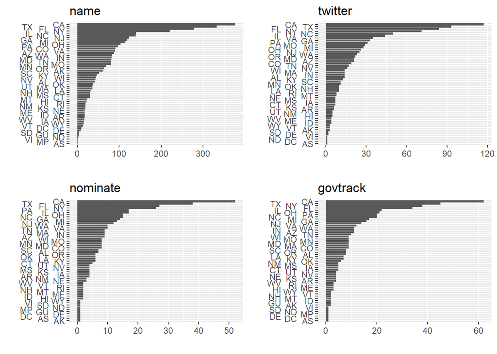

```r
state_bar_plot <- function (data, filter_column) {
  data %>%
    mutate(dupe = duplicated(name)) %>%
    filter(!is.na(!! sym(filter_column)),
           dupe == FALSE) %>%
    group_by(state) %>%
    summarise(count = n()) %>%
    ggplot(aes(x = reorder(state, count), y = count)) +
    geom_bar(stat = 'identity') +
    scale_x_discrete(guide = guide_axis(n.dodge = 3)) +
    xlab('') +
    ylab('') +
    labs(title = str_remove_all(filter_column, 'partisan_score_')) +
    coord_flip()
}

state_plots <- lapply(c('name','partisan_score_twitter',
                        'partisan_score_nominate','partisan_score_govtrack'),
                      state_bar_plot, data = candidates)

plot_grid(plotlist = state_plots, nrow = 2, ncol = 2)
```

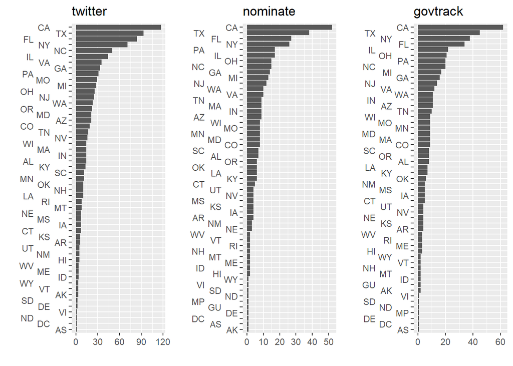

```r
state_plots <- lapply(c('partisan_score_twitter',
                        'partisan_score_nominate',
                        'partisan_score_govtrack'),
                      state_bar_plot, data = candidates)

plot_grid(plotlist = state_plots, nrow = 1, ncol = 3)
```

Spread across parties

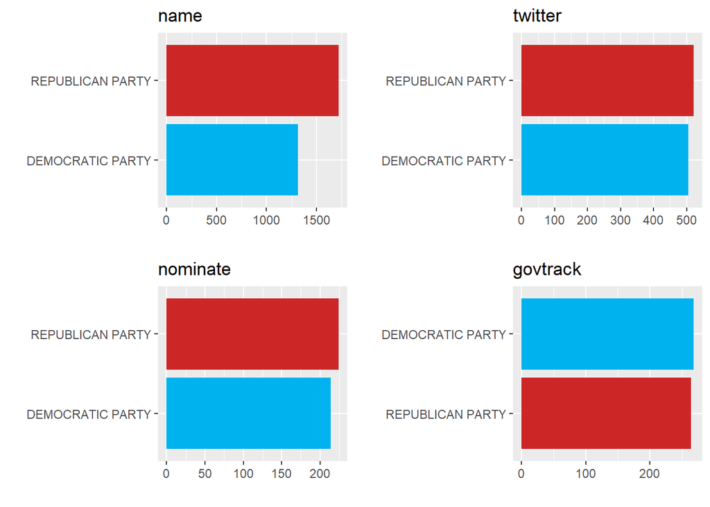

```r
party_bar_plot <- function (data, filter_column) {
  data %>%
    mutate(dupe = duplicated(name)) %>%
    filter(!is.na(!! sym(filter_column)), dupe == FALSE,
           party == 'DEMOCRATIC PARTY' | party == 'REPUBLICAN PARTY') %>%
    group_by(party) %>%
    summarise(count = n()) %>%
    ggplot(aes(x = reorder(party, count), y = count, fill = party)) +
    geom_bar(stat = 'identity', show.legend = FALSE) +
    scale_fill_manual(values = c('DEMOCRATIC PARTY' = 'deepskyblue2',
                                 'REPUBLICAN PARTY' = 'firebrick3')) +
    xlab('') +
    ylab('') +
    labs(title = str_remove_all(filter_column, 'partisan_score_')) +
    coord_flip()
}

party_plots <- lapply(c('name','partisan_score_twitter',
                        'partisan_score_nominate','partisan_score_govtrack'),
                      party_bar_plot, data = candidates)

plot_grid(plotlist = party_plots, nrow = 2, ncol = 2)
```

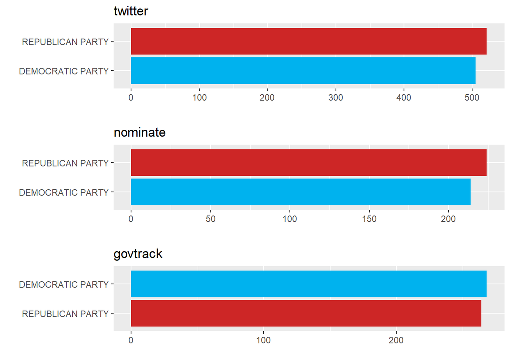

```r
party_plots <- lapply(c('partisan_score_twitter',
                        'partisan_score_nominate',
                        'partisan_score_govtrack'),
                      party_bar_plot, data = candidates)

plot_grid(plotlist = party_plots, nrow = 3, ncol = 1)
```

Geographic Visualization

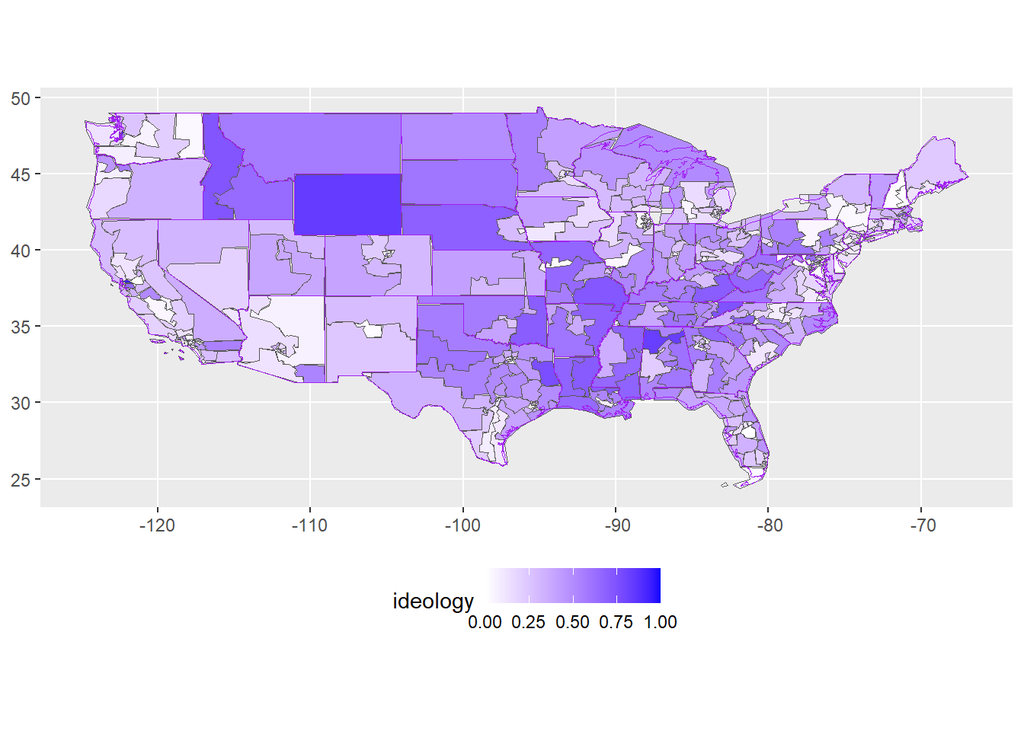

```r
map_plot <- function(fill,
                     color = 'blue',
                     data = candidates_sf) {
  data %>%
    filter(state != 'HI',
           state != 'AK',
           state != 'PR') %>%
    ggplot() +
    geom_sf(aes(geometry = geometry_distr, fill = !!sym(fill))) +
    geom_sf(aes(geometry = geometry_state), color = 'purple', size = 0.4, fill = NA) +
    scale_fill_gradient(low = 'gray100',
                        high = color,
                        limits = c(0,1),
                        name = str_remove_all(fill, 'compete_')) +
    theme(legend.position='bottom')
}

map_plot(fill = 'compete_ideology',
         data = candidates_sf)
```

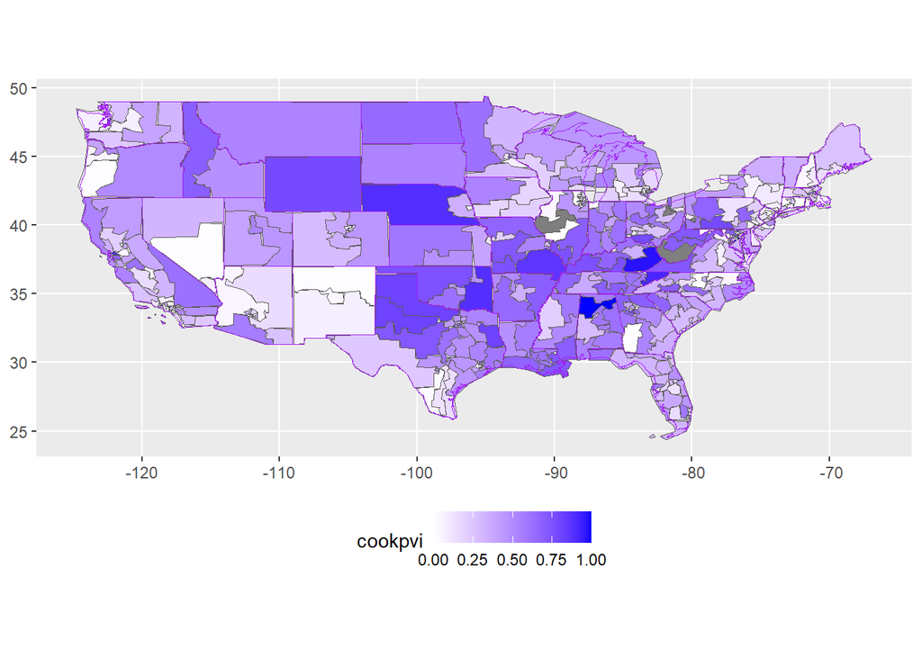

```r
map_plot(fill = 'compete_cookpvi',
         data = candidates_sf)
```

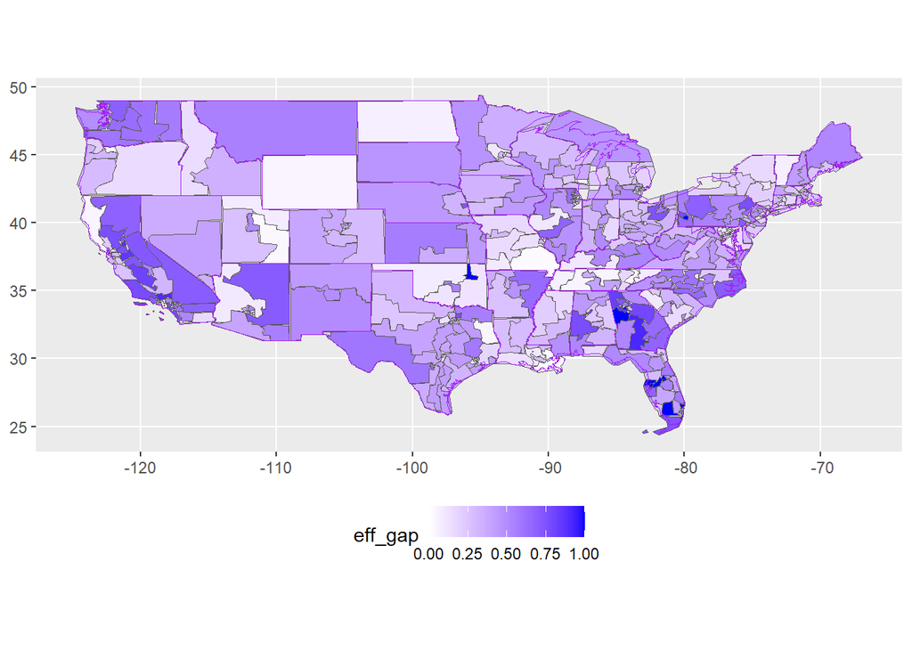

```r
map_plot(fill = 'compete_eff_gap',
         data = candidates_sf)
```

Efficiency and Partisanship

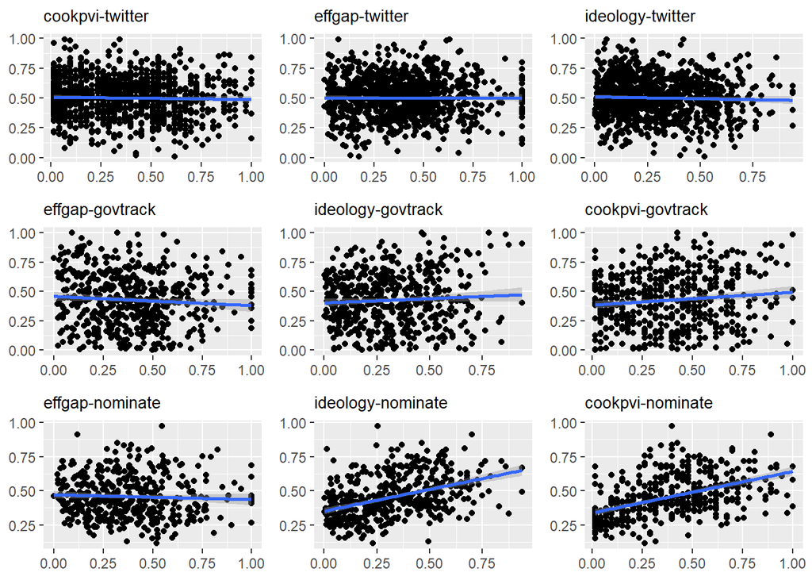

```r
scatterplot <- function(x,y) {
  candidates %>%
  filter(!is.na(!! sym(x)),
         !is.na(!! sym(y))) %>%
  ggplot(aes(x = !! sym(x), y = !! sym(y))) +
  geom_point() +
  geom_smooth(method = 'lm', formula = 'y ~ x') +
  theme(axis.title.x = element_blank(),
        axis.title.y = element_blank(),
        plot.title = element_text(size = 10)) +
  labs(title = str_c(str_remove_all(x, 'compete|_'), '-',
                     str_remove_all(y, 'partisan_score|_')))
}

var_grid_continous <- expand_grid(
  x = colnames(select(candidates, contains('compete'))),
  y = colnames(select(candidates, contains('partisan')))
)

plot_list <- list()

for (row in 1:nrow(var_grid_continous)) {
  plot <- scatterplot(as.character(var_grid_continous[row,'x']),
                      as.character(var_grid_continous[row,'y']))
  plot_list[[ row]] <- plot
}

plot_grid(plotlist = plot_list[c(4,7,1,9,3,6,8,2,5)], nrow = 3, ncol = 3)
```

Summary Stats

```r
cat('District Ideology\n')
```

```
## District Ideology
```

```r
summary(candidates$compete_ideology)
```

```
##    Min. 1st Qu.  Median    Mean 3rd Qu.    Max.    NA's
## 0.00104 0.13089 0.28782 0.31187 0.48419 0.93941     108
```

```r
cat('\nDistrict Cook PVI\n')
```

```
##
## District Cook PVI
```

```r
summary(candidates$compete_cookpvi)
```

```
##    Min. 1st Qu.  Median    Mean 3rd Qu.    Max.    NA's
##  0.0137  0.1507  0.3425  0.3657  0.5343  1.0000     131
```

```r
cat('\nDistrict Effiency Gap\n')
```

```
##
## District Effiency Gap
```

```r
summary(candidates$compete_eff_gap)
```

```
##    Min. 1st Qu.  Median    Mean 3rd Qu.    Max.    NA's
##  0.0000  0.2233  0.3785  0.3932  0.5339  1.0000     192
```

```r
summary(candidates$compete_cookpvi)
```

```
##    Min. 1st Qu.  Median    Mean 3rd Qu.    Max.    NA's
##  0.0137  0.1507  0.3425  0.3657  0.5343  1.0000     131
```

```r
summary(candidates$compete_eff_gap)
```

```
##    Min. 1st Qu.  Median    Mean 3rd Qu.    Max.    NA's
##  0.0000  0.2233  0.3785  0.3932  0.5339  1.0000     192
```

```r
summary(candidates$compete_ideology)
```

```
##    Min. 1st Qu.  Median    Mean 3rd Qu.    Max.    NA's
## 0.00104 0.13089 0.28782 0.31187 0.48419 0.93941     108
```

Binary Independent Variables

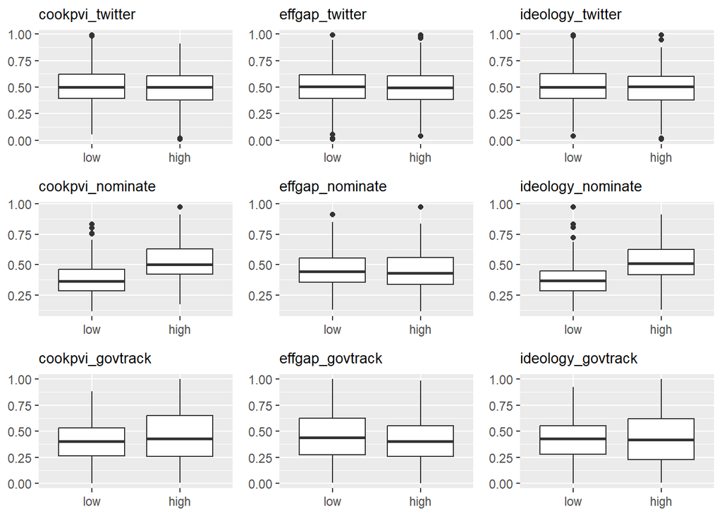

```r
candidates <- candidates %>%
  mutate(
    compete_ideology_binary = factor(if_else(compete_ideology > median(
      candidates$compete_ideology, na.rm = TRUE), 'high', 'low'),
      levels = c('low','high'),
      ordered = TRUE),
    compete_cookpvi_binary = factor(if_else(compete_cookpvi > median(
      candidates$compete_cookpvi, na.rm = TRUE), 'high', 'low'),
      levels = c('low','high'),
      ordered = TRUE),
    compete_eff_gap_binary = factor(if_else(compete_eff_gap > median(
      candidates$compete_eff_gap, na.rm = TRUE), 'high', 'low'),
      levels = c('low','high'),
      ordered = TRUE))

boxplot <- function(x,y) {
  candidates %>%
  filter(!is.na(!! sym(x)),
         !is.na(!! sym(y))) %>%
  ggplot(aes(x = !! sym(x), y = !! sym(y))) +
  geom_boxplot() +
  theme(axis.title.x = element_blank(),
        axis.title.y = element_blank(),
        plot.title = element_text(size = 10)) +
  labs(title = str_c(str_remove_all(x, 'compete|_|binary'), '_',
                     str_remove_all(y, 'partisan_score|_')))
}

var_grid <- expand_grid(
  x = colnames(select(candidates, (contains('compete') & contains('binary')))),
  y = colnames(select(candidates, contains('partisan')))
) %>%
  arrange(x,y)

plot_list <- list()

for (row in 1:nrow(var_grid)) {
  plot <- boxplot(as.character(var_grid[row,'x']),
                  as.character(var_grid[row,'y']))
  plot_list[[ row]] <- plot
}

plot_grid(plotlist = plot_list[c(3,6,9,2,5,8,1,4,7)], nrow = 3, ncol = 3)
```

## Inference

Define functions

```r
hyp_diff_means <- function(x, y,
                           data = candidates,
                           conf_level = 0.95,
                           bootstraps = 1000) {
  mean_diff <- data %>%
    filter(!is.na(!! sym(y)),
           !is.na(!! sym(x))) %>%
    specify(response = (!!sym(y)), explanatory = (!!sym(x))) %>%
    calculate(stat = 'diff in means', order = c('high', 'low'))

  null_dist <- data %>%
    filter(!is.na(!! sym(y)),
           !is.na(!! sym(x))) %>%
    specify(response = (!!sym(y)), explanatory = (!!sym(x))) %>%
    hypothesize(null = 'independence') %>%
    generate(reps = bootstraps, type = 'permute') %>%
    calculate(stat = 'diff in means', order = c('high', 'low'))

  pval <- null_dist %>%
    get_p_value(obs_stat = mean_diff, direction = 'two-sided')

  ci <- data %>%
    filter(!is.na(!! sym(y)),
           !is.na(!! sym(x))) %>%
    specify(response = (!!sym(y)), explanatory = (!!sym(x))) %>%
    generate(reps = bootstraps, type = 'bootstrap') %>%
    calculate(stat = 'diff in means', order = c('high', 'low')) %>%
    get_ci(level = conf_level)

  results <- list(p_value = pval$p_value,
                  lower_ci = ci$lower_ci,
                  upper_ci = ci$upper_ci,
                  mean_diff = mean_diff$stat)

  return(results)
}

grid_hyp_test <- function(data, grid, ...) {

  results_df <- data.frame(grid, p_value = NA, lower_ci = NA,
                           upper_ci = NA, mean_diff = NA)

  for (row in 1:nrow(grid)) {

    test_name <- str_c(str_remove_all(as.character(grid[row,'x']),
                                      'compete|_|binary'), '_',
                       str_remove_all(as.character(grid[row,'y']),
                                      'partisan_score|_'))

    result <- hyp_diff_means(as.character(grid[row,'x']),
                             as.character(grid[row,'y']),
                             data = data)

    results_df <- results_df %>%
      mutate(
        p_value = replace(p_value,
                          x == as.character(grid[row,'x']) &
                            y == as.character(grid[row,'y']),
                          result$p_value),
        lower_ci = replace(lower_ci,
                           x == as.character(grid[row,'x']) &
                             y == as.character(grid[row,'y']),
                           result$lower_ci),
        upper_ci = replace(upper_ci,
                           x == as.character(grid[row,'x']) &
                             y == as.character(grid[row,'y']),
                           result$upper_ci),
        mean_diff = replace(mean_diff,
                           x == as.character(grid[row,'x']) &
                             y == as.character(grid[row,'y']),
                           result$mean_diff))
  }

  return(results_df)

}

hyp_test_heatmap <- function(results_df, upper_limit = 0.1) {
  results_df %>%
    mutate(x = str_remove_all(x, 'compete|binary|_'),
           y = str_remove_all(y, 'partisan_score|_')) %>%
    ggplot(aes(x, y)) +
    geom_tile(aes(fill = p_value)) +
    geom_text(aes(label = str_c('Obs. Diff.: ', round(mean_diff,3),
                                '\np-value: ',
                                if_else(p_value == 0, '<0.000',
                                        format(round(p_value,3), nsmall=3)),
                                '\n95% CI: ', round(lower_ci,3),
                                ' to ', round(upper_ci,3)))) +
    xlab('District Competition Measures') +
    ylab('Candidate Partisanship Measures') +
    theme(axis.text.y = element_text(angle = 90, hjust = 0.5)) +
    scale_fill_gradient(low = 'darkslategray1',
                        high = 'gray100',
                        limits = c(0,upper_limit),
                        oob = scales::squish)
                        # na.value = 'grey50')

}
```

Run test on full data

```r
results <- grid_hyp_test(data = candidates, grid = var_grid)
```

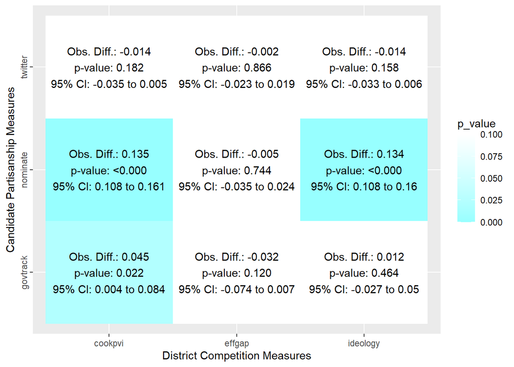

```r
hyp_test_heatmap(results)
```

Split by party

```r
results_dem <- grid_hyp_test(data = filter(candidates,
                                           party == 'DEMOCRATIC PARTY'),
                             grid = var_grid,
                             conf_level = 0.975)
results_rep <- grid_hyp_test(data = filter(candidates,
                                           party == 'REPUBLICAN PARTY'),
                             grid = var_grid,
                             conf_level = 0.975)
```

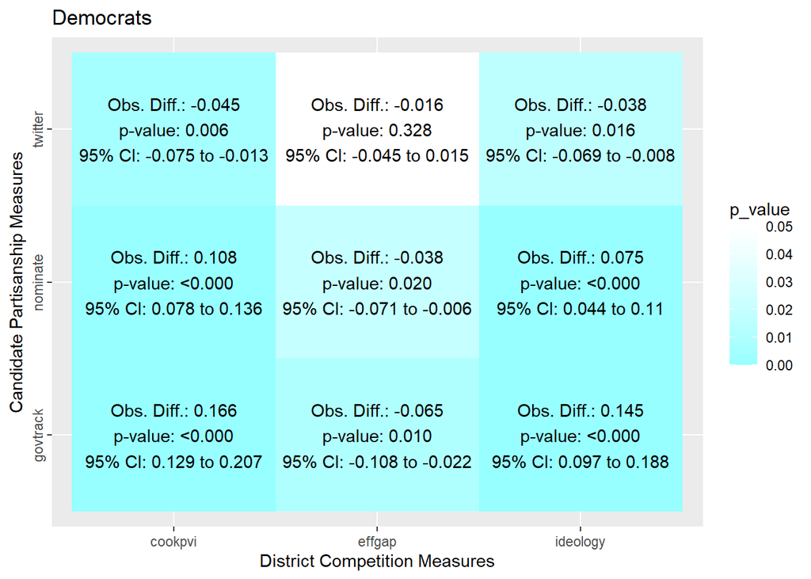

```r
hyp_test_heatmap(results_dem, upper_limit = 0.05) +
  labs(title = 'Democrats')
```

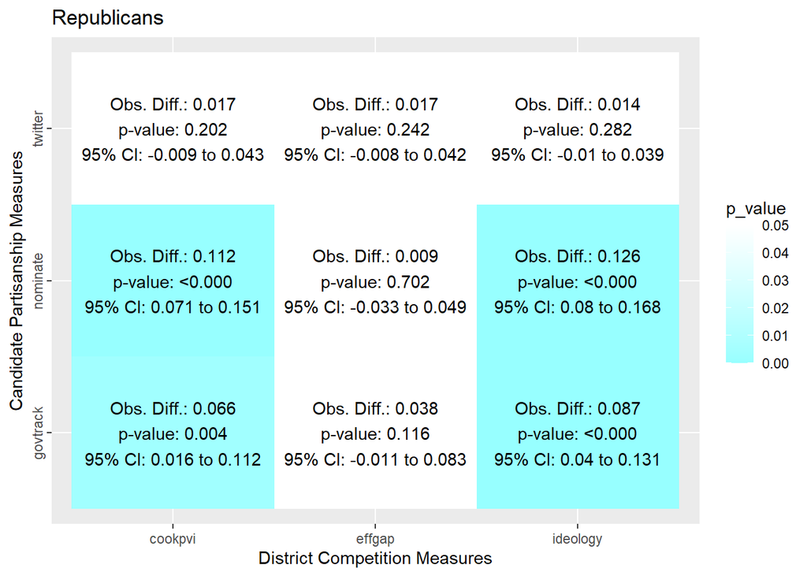

```r
hyp_test_heatmap(results_rep, upper_limit = 0.05) +
  labs(title = 'Republicans')
```

## Linear Regression

```r
results_df <- data.frame(var_grid_continous,
                         beta_coef = NA,
                         predictor_pval = NA,
                         r_squared = NA)
model_list <- list()

for (row in 1:nrow(var_grid_continous)) {
  x = as.character(var_grid_continous[row,'x'])
  y = as.character(var_grid_continous[row,'y'])

  model <- lm(data = candidates, formula = as.formula(paste(y,'~',x)))

  model_list[[ row]] <- model

  results_df <- results_df %>%
      mutate(
        beta_coef = replace(beta_coef,
                          x == as.character(var_grid_continous[row,'x']) &
                            y == as.character(var_grid_continous[row,'y']),
                          summary(model)$coefficients[2]),
        predictor_pval = replace(predictor_pval,
                           x == as.character(var_grid_continous[row,'x']) &
                             y == as.character(var_grid_continous[row,'y']),
                           summary(model)$coefficients[8]),
        r_squared = replace(r_squared,
                           x == as.character(var_grid_continous[row,'x']) &
                             y == as.character(var_grid_continous[row,'y']),
                          summary(model)$r.squared))
}

results_df %>%
  filter(predictor_pval < 0.1) %>%
  arrange(desc(r_squared))
```

```
##                  x                       y  beta_coef predictor_pval
## 1  compete_cookpvi partisan_score_nominate  0.3040729   6.683363e-26
## 2 compete_ideology partisan_score_nominate  0.3184230   1.037703e-20
## 3  compete_cookpvi partisan_score_govtrack  0.1099427   5.712276e-03
## 4  compete_eff_gap partisan_score_govtrack -0.0785671   7.348125e-02
##     r_squared
## 1 0.222758558
## 2 0.179384003
## 3 0.014323040
## 4 0.006066025
```

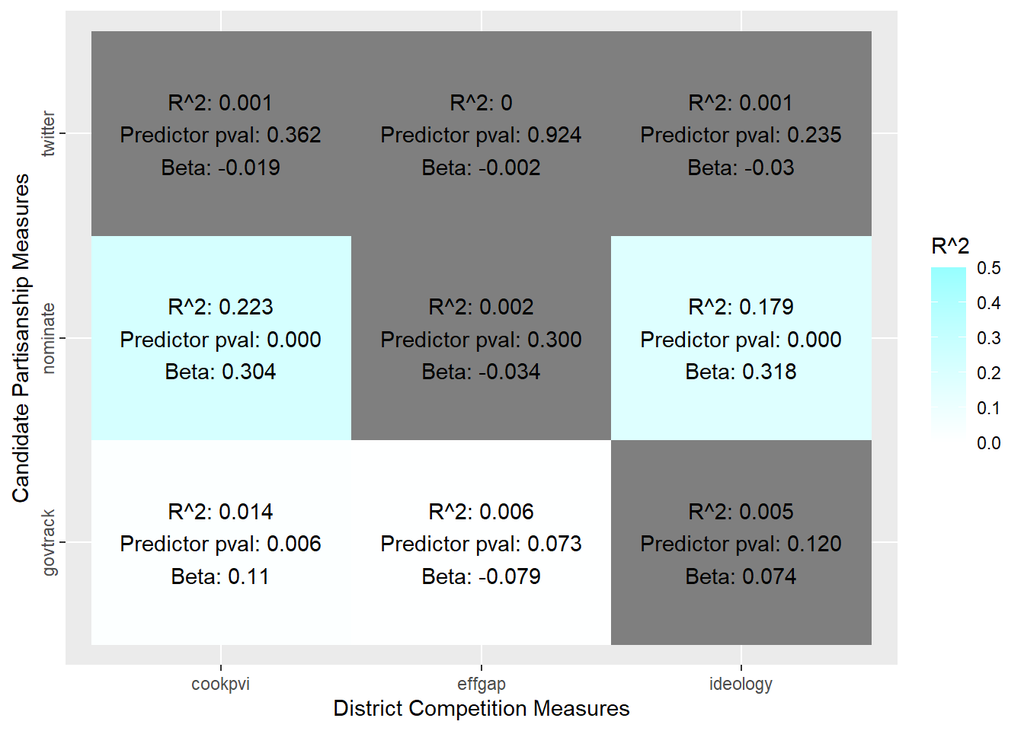

```r
results_df %>%
  mutate(x = str_remove_all(x, 'compete|_'),
         y = str_remove_all(y, 'partisan_score|_')) %>%
  ggplot(aes(x,y)) +
  geom_tile(aes(fill = ifelse(predictor_pval < 0.1, r_squared, NA))) +
  geom_text(aes(label = str_c('R^2: ',round(r_squared,3),
                              '\nPredictor pval: ',format(round(predictor_pval,3), nsmall=3),
                              '\nBeta: ',round(beta_coef,3)))) +
  xlab('District Competition Measures') +
  ylab('Candidate Partisanship Measures') +
  scale_fill_gradient(low = 'gray100',
                      high = 'darkslategray1',
                      limits = c(0,0.5),
                      na.value = 'grey50') +
  theme(axis.text.y = element_text(angle = 90, hjust = 0.5)) +
  labs(fill = 'R^2')
```

Residual Plots

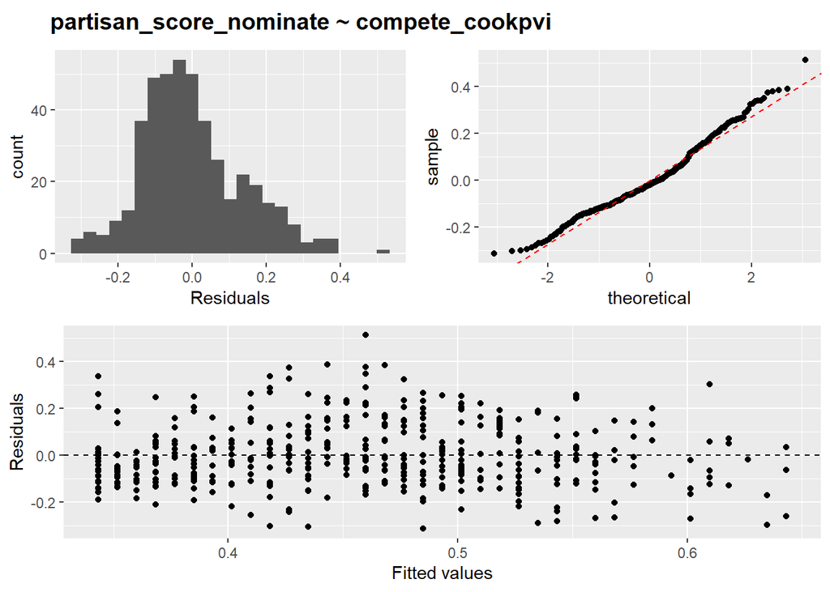

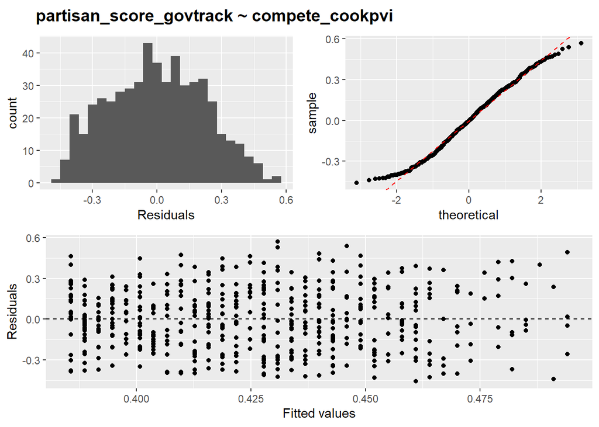

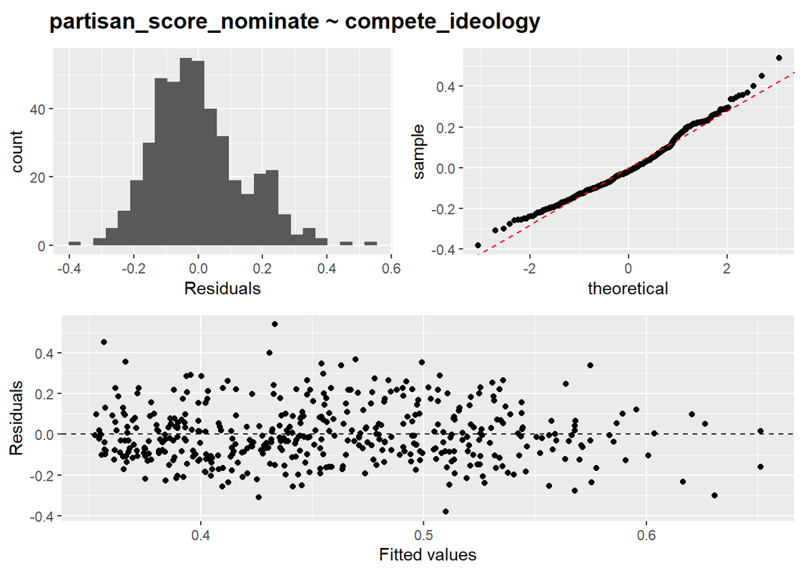

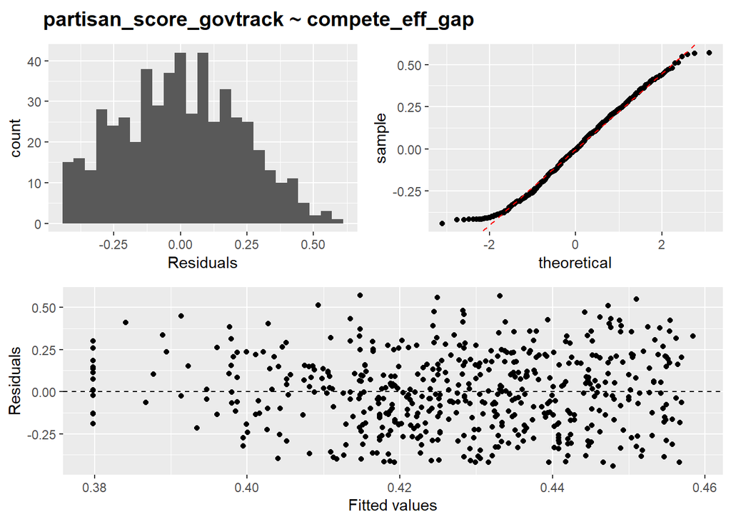

```r
for (i in c(5, 6, 2, 9)) {

  p1 <- ggplot(data =   model_list[[i]], aes(x = .resid)) +
    geom_histogram(bins = 25) +
    xlab("Residuals")

  p2 <- ggplot(data =   model_list[[i]], aes(sample = .resid)) +
    stat_qq() +
    geom_abline(intercept = mean(model_list[[i]]$residuals),
                slope = sd(model_list[[i]]$residuals),
                color = 'red', linetype = 'dashed')


  p3 <- ggplot(data = model_list[[i]], aes(x = .fitted, y = .resid)) +
    geom_point() +
    geom_hline(yintercept = 0, linetype = "dashed") +
    xlab("Fitted values") +
    ylab("Residuals")

  formula <- str_c(as.character(model_list[[i]]$terms[1])[2],' ',
                   as.character(model_list[[i]]$terms[1])[1],' ',
                   as.character(model_list[[i]]$terms[1])[3])

  title <- ggdraw() +
    draw_label(formula, fontface = 'bold', x = 0, hjust = -0.1)

  print(plot_grid(title, plot_grid(p1, p2), p3,
                  nrow = 3, ncol = 1, rel_heights = c(0.15,1,1)))
}
```

```r
for (i in c(5, 6, 2, 9)) {

  print(summary(model_list[[i]]))

}
```

```
##
## Call:
## lm(formula = as.formula(paste(y, "~", x)), data = candidates)
##
## Residuals:
##      Min       1Q   Median       3Q      Max
## -0.31291 -0.09256 -0.02076  0.07328  0.51309
##
## Coefficients:
##                 Estimate Std. Error t value Pr(>|t|)
## (Intercept)      0.33912    0.01232   27.54   <2e-16 ***
## compete_cookpvi  0.30407    0.02708   11.23   <2e-16 ***
## ---
## Signif. codes:  0 '***' 0.001 '**' 0.01 '*' 0.05 '.' 0.1 ' ' 1
##
## Residual standard error: 0.1365 on 440 degrees of freedom
##   (3285 observations deleted due to missingness)
## Multiple R-squared:  0.2228, Adjusted R-squared:  0.221
## F-statistic: 126.1 on 1 and 440 DF,  p-value: < 2.2e-16
##
##
## Call:
## lm(formula = as.formula(paste(y, "~", x)), data = candidates)
##
## Residuals:
##      Min       1Q   Median       3Q      Max
## -0.45740 -0.16191 -0.00229  0.16626  0.56915
##
## Coefficients:
##                 Estimate Std. Error t value Pr(>|t|)
## (Intercept)      0.38416    0.01767  21.742  < 2e-16 ***
## compete_cookpvi  0.10994    0.03962   2.775  0.00571 **
## ---
## Signif. codes:  0 '***' 0.001 '**' 0.01 '*' 0.05 '.' 0.1 ' ' 1
##
## Residual standard error: 0.2219 on 530 degrees of freedom
##   (3195 observations deleted due to missingness)
## Multiple R-squared:  0.01432,    Adjusted R-squared:  0.01246
## F-statistic: 7.702 on 1 and 530 DF,  p-value: 0.005712
##
```

[output cut: 24 more lines]

```
## Residuals:
##      Min       1Q   Median       3Q      Max
## -0.44154 -0.16717 -0.00503  0.16262  0.57069
##
## Coefficients:
##                 Estimate Std. Error t value Pr(>|t|)
## (Intercept)      0.45839    0.01981  23.141   <2e-16 ***
## compete_eff_gap -0.07857    0.04381  -1.793   0.0735 .
## ---
## Signif. codes:  0 '***' 0.001 '**' 0.01 '*' 0.05 '.' 0.1 ' ' 1
##
## Residual standard error: 0.2249 on 527 degrees of freedom
##   (3198 observations deleted due to missingness)
## Multiple R-squared:  0.006066,   Adjusted R-squared:  0.00418
## F-statistic: 3.216 on 1 and 527 DF,  p-value: 0.07348
```

Correlation

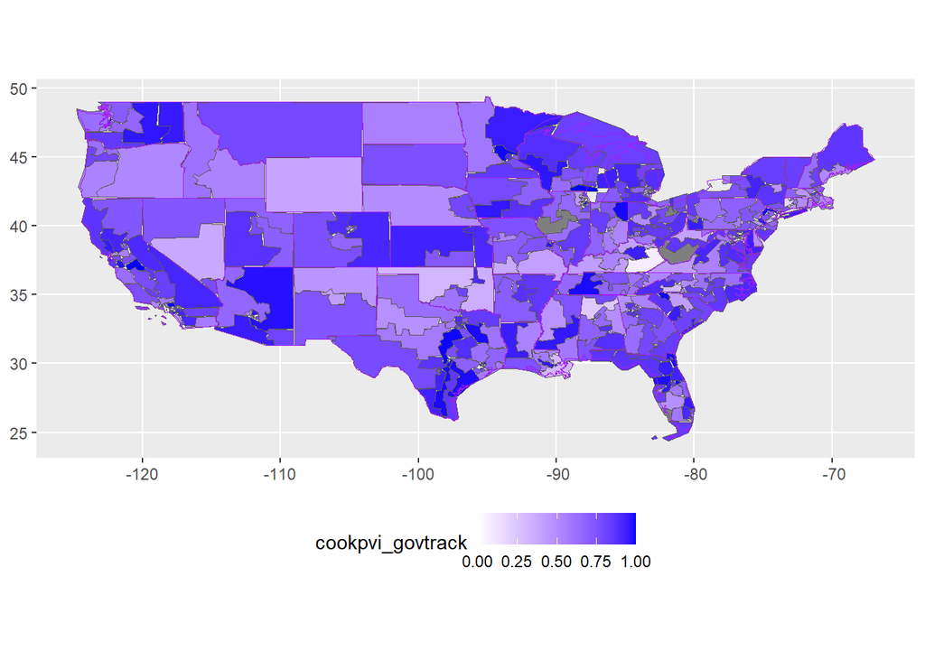

```r
candidates_sf <- candidates_sf %>%
  mutate(
    cookpvi_nominate = abs(compete_cookpvi - partisan_score_nominate),
    cookpvi_govtrack = abs(compete_cookpvi - partisan_score_govtrack),
    ideology_nominate = abs(compete_ideology - partisan_score_nominate))

candidates_sf_summarized <- candidates_sf %>%
  group_by(state, district, geometry_state, geometry_distr) %>%
  summarize(cookpvi_nominate = 1 - mean(cookpvi_nominate, na.rm = T),
            cookpvi_govtrack = 1 - mean(cookpvi_govtrack, na.rm = T),
            ideology_nominate = 1 - mean(ideology_nominate, na.rm = T),
            .groups = 'keep')

map_plot(fill = 'cookpvi_govtrack',
         data = candidates_sf_summarized)
```